# レポート課題 第5回 課題２

氏名：木澤 祐人  
学籍番号：2094572t

## Googleドライブのマウントとフォルダへの移動

```python
from google.colab import drive
drive.mount('/content/drive')
%cd /content/drive/'My Drive'/情報管理/05/
```

```
/content/drive/My Drive/情報管理/05
```

## 必要なライブラリのインポート

```python
import pandas as pd
import numpy as np
import matplotlib.pyplot as plt
```

## データの読み込み

```python
csv_data = pd.read_csv('xyz.csv', encoding='SHIFT-JIS')
display(csv_data.head())

X = csv_data.loc[:,'x':].to_numpy()
y = csv_data.loc[:,'クラス']

(num_samples, num_dimensions) = np.shape(X)
print('Information of scores (X)')
print('  Nunber of samples: ' + str(num_samples))
print('  Number of dimensions: ' + str(num_dimensions))

classes = y.unique()
num_classes = np.size(classes)

print('Classes:' + str(classes))
print('Number of classes: ' + str(num_classes))
```

|  | クラス | x | y | z |
| --- | --- | --- | --- | --- |
| 0 | 0 | -8.731 | 10.279 | 0.612 |
| 1 | 1 | 89.659 | -40.555 | 4.781 |
| 2 | 1 | -94.955 | 9.869 | 6.040 |
| 3 | 0 | 2.267 | -15.268 | -17.131 |
| 4 | 1 | -104.832 | 38.049 | 5.512 |

```
Information of scores (X)
  Nunber of samples: 400
  Number of dimensions: 3
Classes:[0 1]
Number of classes: 2
```

このデータは（x, y, z）の座標の組み合わせを 400個 記録したもので、  
それぞれの組み合わせは 0 または 1 のいずれかのクラスに属している。  
座標の情報は変数 `X` に格納されており、  
座標ごとのクラス番号は y に格納されている。  
すなわち，クラス数 num_classes = 2 である。

## データの標準化

分析の前処理としてデータの標準化を行う。

```python
mu = np.mean(X, axis=0)
std = np.std(X, axis=0)

X_norm = (X - mu) / std
```

## 線形判別分析

まずはじめに準備として，クラス内分散共分散行列`cov_inner`とクラス間分散共分散行列`cov_intra`を計算する。

```python
m_all = np.mean(X_norm, axis=0)

cov_inner = np.zeros((num_dimensions, num_dimensions))
for n in range(num_classes):
  X_tmp = X_norm[y==n]
  m = np.mean(X_tmp, axis=0)
  cov_inner += np.dot((X_tmp-m).T, (X_tmp-m))

cov_intra = np.zeros((num_dimensions, num_dimensions))
for n in range(num_classes):
  X_tmp = X_norm[y==n]
  num_samples_n, num_dimensions = np.shape(X_tmp)
  m = np.mean(X_tmp, axis=0)

  m_sub = m - m_all
  m_sub = np.reshape(m_sub, (-1,1))
  cov_intra += num_samples_n * np.dot(m_sub, m_sub.T)
```

次に、クラス内分散の逆行列とクラス間分散の内積を計算し，計算結果に対して固有値分解を行う。  
その後，固有値の大きい順に固有ベクトルを並べ替える。

```python
J = np.dot(np.linalg.inv(cov_inner), cov_intra)

eig_val, eig_vec =np.linalg.eig(J)
eig_val = np.real(eig_val)
eig_vec = np.real(eig_vec)

order = np.argsort(eig_val)[::-1]
eig_val = eig_val[order]
eig_vec_lda = eig_vec[:,order]
```

最後に、第一および第二固有ベクトルを使って，データを二次元に圧縮する。

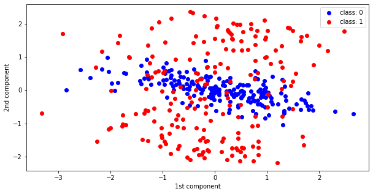

```python
X_lda = np.dot(X_norm, eig_vec_lda[:,:2])

color_set = ['b', 'r']
plt.figure(figsize=(10,5))
for n in range(num_classes):
  plt.scatter(X_lda[y==n,0], X_lda[y==n,1], color=color_set[n], label='class: '+str(n))
plt.xlabel('1st component')
plt.ylabel('2nd component')
plt.legend()
plt.show()
```

線形判別分析によって2次元圧縮した結果は、クラス1が広範囲に分散し、クラス0の分布の大部分がクラス1に重複しているため、線形判別分析がうまく機能しているとは言えない。

## 考察

分析に使用した固有ベクトルを確認する。

```python
print(eig_vec_lda[:, :2])
```

```
[[-0.00170157 -0.18556454]
 [-0.28822324 -0.94677056]
 [-0.95756173  0.26304241]]
```

上の結果から、  
一つ目の軸は z に、二つ目の軸は y に絶対値0.9以上の非常に大きな比重が負の値でかけられていることがわかる。  
したがって、横軸と縦軸ではそれぞれ z, y が小さいほど正の方向に、大きいほど負の方向に大きくなる。  
これらを踏まえ、分析がうまくいかない原因を調べるためにクラス1に関するデータの分散共分散行列を求める。

```python
cov = np.zeros((num_dimensions, num_dimensions))
tmp = X_norm[y==1]
n = np.mean(tmp, axis=0)
cov += np.dot((tmp-n).T, (tmp-n))

print(cov)
```

```
[[382.17310362 -56.73694525  12.82576106]
 [-56.73694525 385.03225617 -10.16038913]
 [ 12.82576106 -10.16038913 196.97313109]]
```

上の結果からわかるように、  
クラス1のデータでは x, y が380以上、zが190以上の極端に大きな分散を持っている。  
この大きな分散が判別分析に悪影響を及ぼしていると考えられる。  
そこで、分析に異なる固有ベクトルを用いることを試みる。  
先ほど求めたクラス1の分散共分散行列の非対角成分に着目すると、(0, 1)成分と(1, 0)成分の絶対値が他の非対角成分の4倍以上大きい。 すなわち、クラス1のデータにおいて x と y の間には比較的高い相関があると考えられる。

```python
X_lda = np.dot(X_norm, eig_vec_lda[:,1:3])
print(eig_vec_lda[:, 1:3])
```

```
[[-0.18556454  0.9843787 ]
 [-0.94677056  0.17338597]
 [ 0.26304241 -0.03059213]]
```

このように、  
第三の固有ベクトルに対応する軸は x に絶対値0.9以上の非常に大きな比重が正の値でかけられていることから、  
この軸では x が大きいほど正の方向に、小さいほど負の方向に大きくなる。  
以上を踏まえ、第二及び第三固有ベクトルを使った分析結果を次に示す。

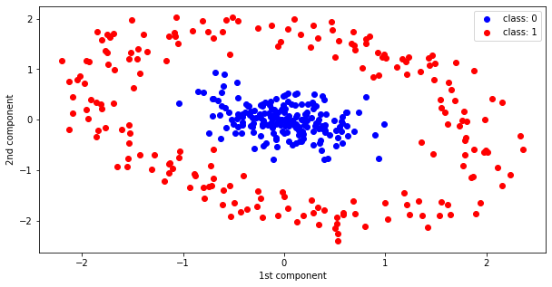

```
[[-0.18556454  0.9843787 ]
 [-0.94677056  0.17338597]
 [ 0.26304241 -0.03059213]]
```

```python
color_set = ['b', 'r']
plt.figure(figsize=(10,5))
for n in range(num_classes):
  plt.scatter(X_lda[y==n,0], X_lda[y==n,1], color=color_set[n], label='class: '+str(n))
plt.xlabel('1st component')
plt.ylabel('2nd component')
plt.legend()
plt.show()

print(eig_vec_lda[:, 1:3])
```

今回の結果では先ほどと異なり、  
同一クラスが密集し、  
かつ  
異なるクラスの分布が離れはっきり区別できるようになった。  
したがって、より精度の高い判別が行えたと言える。